# Número Básico de Reproducción en México

septiembre 12, 2020

El Número Básico de Reproducción es la cantidad esperada de infecciones generadas por un caso. Puede ser utilizado para determinar si debemos establecer medidas de distanciamiento social.

- El número básico de reproducción, $R_t$ representa el número promedio de contagios que una persona infectada realiza. Un valor de $R_t>1$ significa que el número de infectados está creciendo, y se duplicarán en un periodo cuantificable, mientras que un valor de $R_t<1$ significa que el número de infectados tiende disminuir en el tiempo.
- Para cada estado, el método modela la distribución de casos reportados en el pasado para predecir el número de infecciones diarias para cada fecha dentro del periodo de la epidemia.
- Para generar los estimados de $R_t$, utilizamos los datos hechos públicos por la Secretaría de Salud de México.

[figure not shown]

[figure not shown]

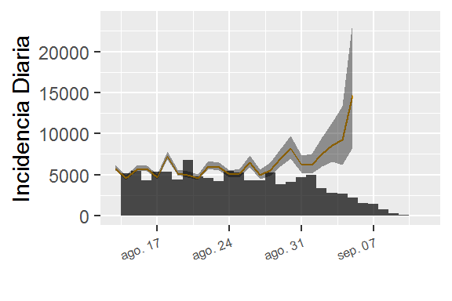

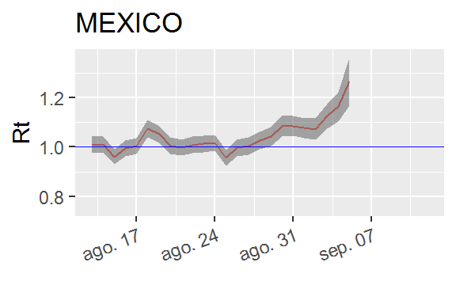

```
##    Rt     sd      fecha
##  1.27 0.0982 2020-09-05
```

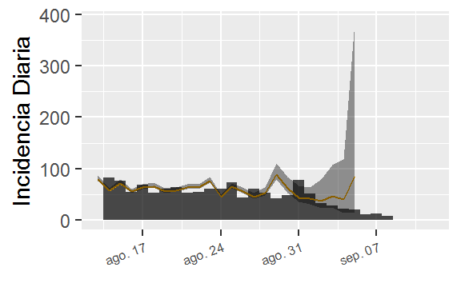

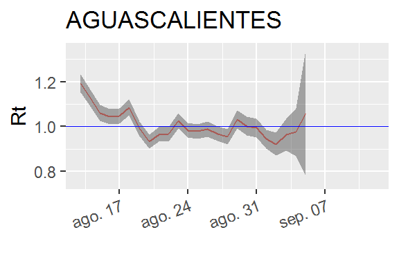

```
##    Rt    sd      fecha
##  1.06 0.281 2020-09-05
```

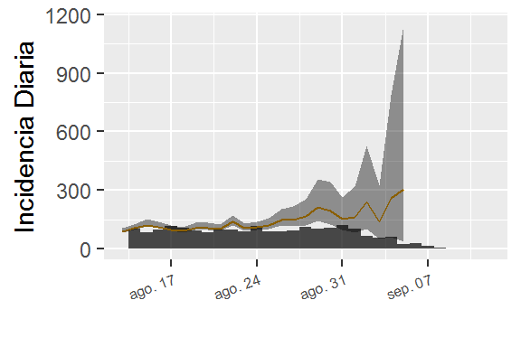

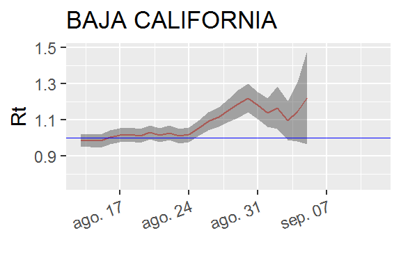

```
##    Rt   sd      fecha
##  1.23 0.26 2020-09-05
```

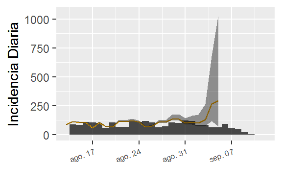

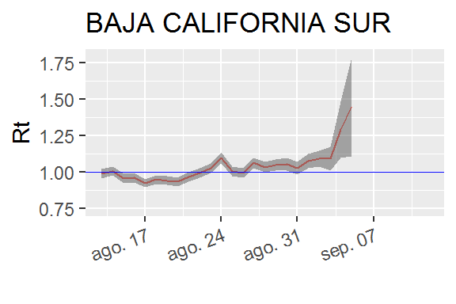

```
##    Rt    sd      fecha
##  1.45 0.339 2020-09-05
```

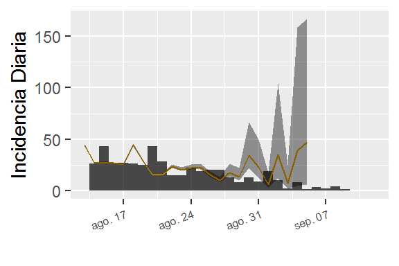

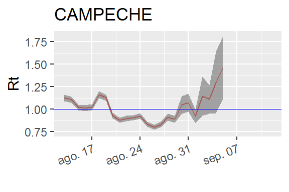

```
##    Rt   sd      fecha
##  1.46 0.35 2020-09-05
```

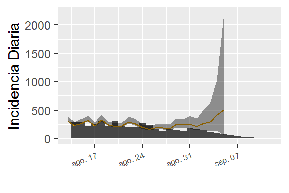

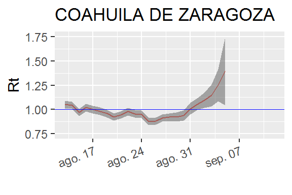

```
##   Rt    sd      fecha
##  1.4 0.351 2020-09-05
```

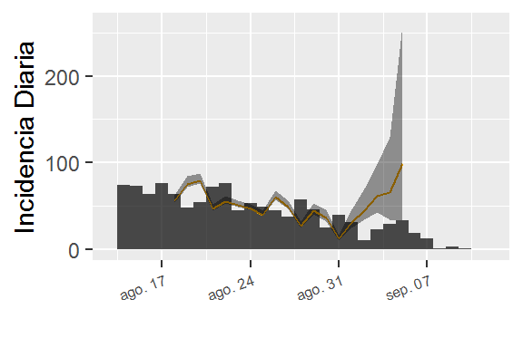

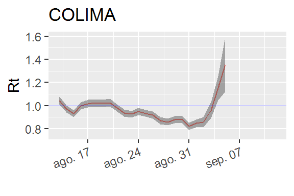

```
##    Rt    sd      fecha
##  1.36 0.237 2020-09-05
```

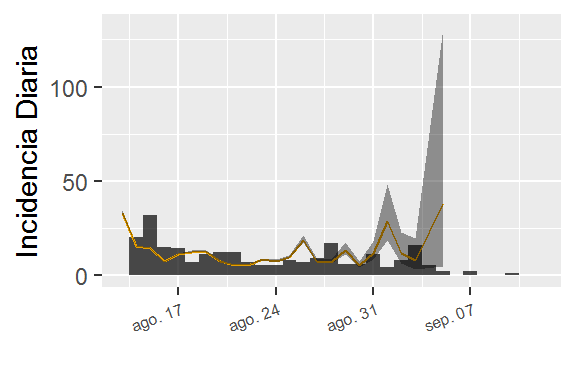

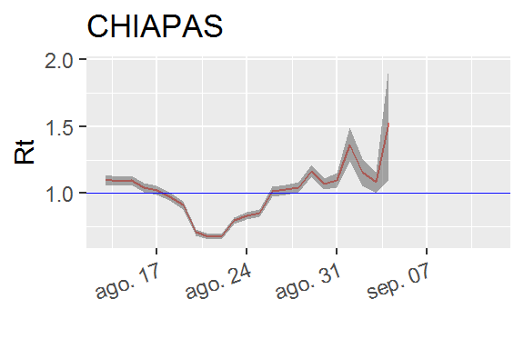

```
##    Rt    sd      fecha
##  1.53 0.426 2020-09-04
```

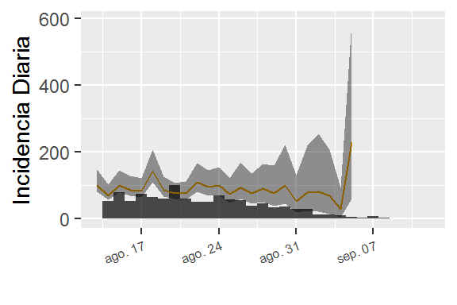

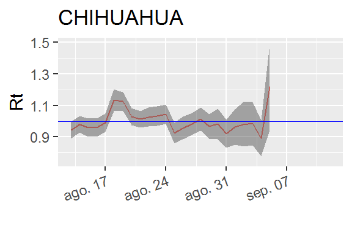

```
##    Rt    sd      fecha
##  1.22 0.272 2020-09-05
```

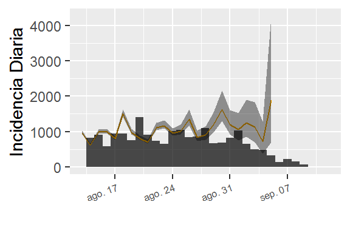

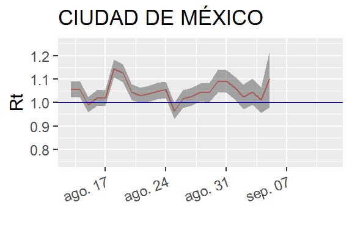

```
##   Rt    sd      fecha
##  1.1 0.121 2020-09-05
```

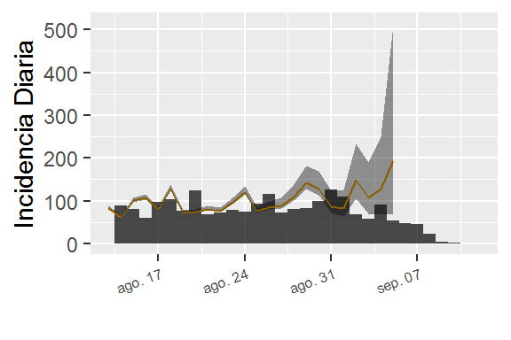

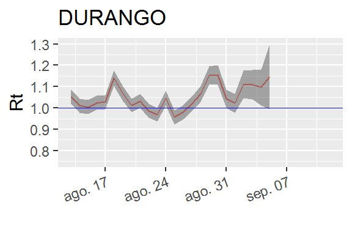

```
##    Rt    sd      fecha
##  1.15 0.153 2020-09-05
```

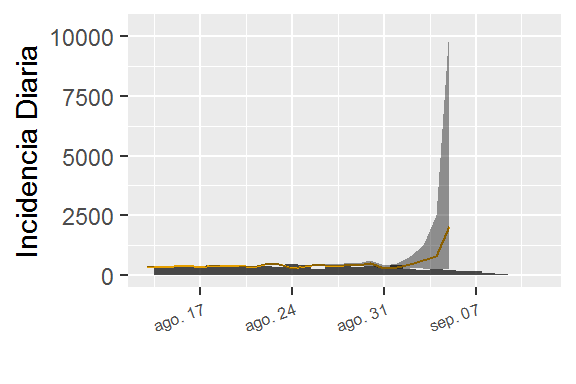

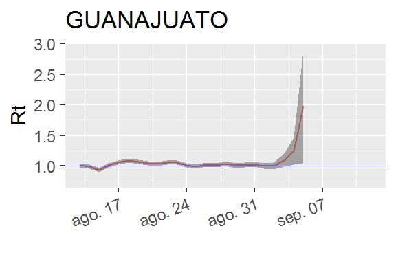

```
##    Rt    sd      fecha
##  1.98 0.926 2020-09-05
```

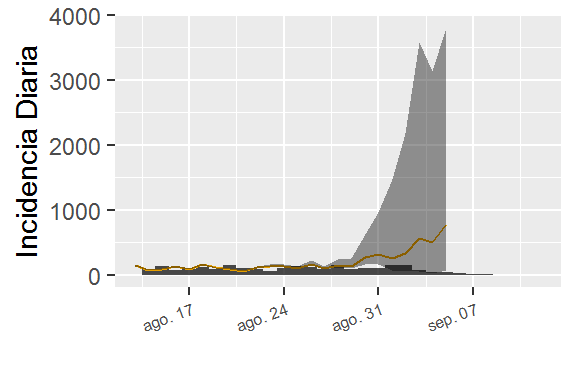

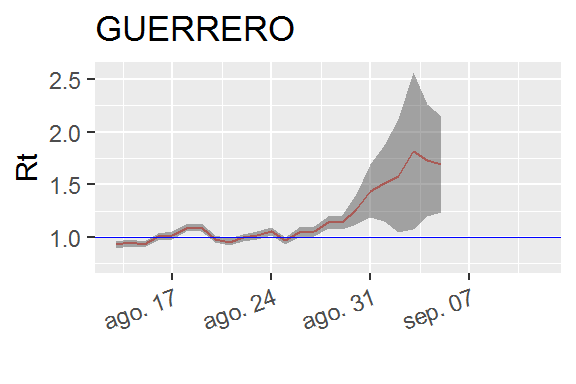

```
##    Rt    sd      fecha
##  1.69 0.458 2020-09-05
```

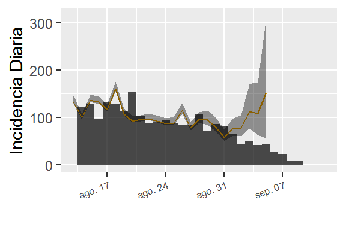

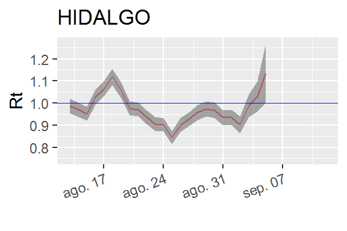

```
##    Rt    sd      fecha
##  1.14 0.133 2020-09-05
```

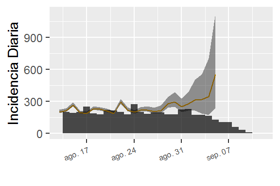

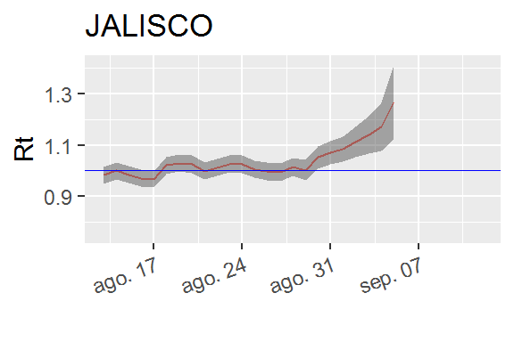

```
##    Rt    sd      fecha
##  1.27 0.146 2020-09-05
```